# Relation Prediction in Argument Mining With Pre-trained Deep Bidirectional Transformers - Core

This notebook generates or shows all plots and tables used in the thesis. Some additional interesting material not mentioned or shown in the thesis, can be found in the other notebook. To run this file, first make sure that all requirements are satisified. The README has detailed information about how to satisfy the requirements. Not all training settings have to be retrained to run this notebook, the cells belonging to training settings not done will be simply skipped. The order is the same as in the thesis.

## Table of Contents:

1. Materials and Methods
2. Comparative Experiments
3. Additional Experiments
4. Critical Analysis

## Setup

The following cells import and load the necessary data and libraries.

```python
# Necessary imports and setups
# Basic python imports
import re
import sys
import os

# For the sentiment baselines
import nltk
# Download Sentiment Lexicon
nltk.download('vader_lexicon')

# Datahandling and plotting
import numpy as np
import pandas as pd
import matplotlib.pyplot as plt

# Statistics and other stuff
from sklearn.metrics import precision_recall_fscore_support, accuracy_score, classification_report
from wordcloud import WordCloud, STOPWORDS
from nltk.sentiment.vader import SentimentIntensityAnalyzer
from pytorch_pretrained_bert.tokenization import BertTokenizer


# Get the exact splits of the data
sys.path.append(os.path.abspath("../pytorch"))
from run_classifier_dataset_utils import processors

# Settings
# Do no hide rows in pandas
pd.set_option('display.max_rows', 164)
pd.set_option('precision', 2)
```

```python
# Read all necessary data
df = pd.read_csv('../data/complete_data.tsv', sep='\t').astype({"id": str})
data_stats_org = np.load('../data/stats/data_stats_org.npy', allow_pickle=True).item()
data_stats_resp = np.load('../data/stats/data_stats_resp.npy', allow_pickle=True).item()
data_stats_topic = np.load('../data/stats/data_stats_topic.npy', allow_pickle=True).item()
data_stats_author = pd.read_csv('../data/stats/data_stats_author.tsv', sep='\t')
data_nix_ken = pd.read_csv('../data/stats/data_nix_ken.tsv', sep='\t')

# Init the data processors and get the correct labels
node_pro = processors['node']('both')
_, node_test_df = node_pro.get_dev_examples('../data')
political_ru_pro = processors['political-ru']('both')
pol_ru_test_df = pd.concat(np.array(political_ru_pro.get_splits('../data'))[:,3])
political_as_pro = processors['political-as']('both')
pol_as_test_df = pd.concat(np.array(political_as_pro.get_splits('../data'))[:,3])
political_asu_pro = processors['political-asu']('both')
pol_asu_test_df = pd.concat(np.array(political_asu_pro.get_splits('../data'))[:,3])
agreement_pro = processors['agreement']('both')
ag_test_df = pd.concat(np.array(agreement_pro.get_splits('../data'))[:,3])
political_ru_topics_pro = processors['political-ru-topics']('both')
pol_ru_to_test_df = pd.concat(np.array(political_ru_topics_pro.get_splits('../data'))[:,3])
political_as_topics_pro = processors['political-as-topics']('both')
pol_as_to_test_df = pd.concat(np.array(political_as_topics_pro.get_splits('../data'))[:,3])
agreement_topics_pro = processors['agreement-topics']('both')
_, ag_to_test_df = agreement_topics_pro.get_dev_examples('../data')

# Init the sentiment analyzer
sid = SentimentIntensityAnalyzer()

# Define helper functions
def get_major_acc(x, classes=['Unrelated', 'Attack/Disagreement', 'Support/Agreement']):
    """Returns the accuracy of the major class."""
    return np.divide(x[classes].max(), np.sum(x[classes]))

def get_major_class(x, classes=['Unrelated', 'Attack/Disagreement', 'Support/Agreement']):
    """Returns the name of the major class."""
    return x[classes].astype('float64').idxmax()

def disc_pol(x):
    """Discretize the float sentiment polarity."""
    if x >= 0.00:
        return 'positive'
    else:
        return 'negative'

def count_values(x, labels):
    """Count how many rows in x have a label in labels."""
    return x['label'].loc[x['label'].isin(labels)].count()

def convert_preds_topic(df_preds, df_res, replace_dict, count, print_clr=True):
    """Prints the classification reports for every topic."""
    labels = list(replace_dict.values())
    preds = pd.Series()
    for i, row in df_preds.iterrows():
        preds = preds.append(pd.Series(row.values[~row.str.contains('bert*', na=False, regex=True)]))
        if i == count:
            break
    preds = preds.dropna().astype(int)
    df_res['preds'] = preds.values
    df_res = df_res.replace(replace_dict)

    if print_clr:
        for name, group in df_res.groupby('topic'):
            print("Topic: {}".format(name))
            print(classification_report(group['label'], group['preds'], labels=labels))

    #display(pd.crosstab(df_res['topic'], [df_res['label'], df_res['preds']]))
    results_topic = pd.crosstab(df_res['topic'], [df_res['label'], df_res['preds']])
    results_topic['total'] = results_topic.agg([np.sum], axis=1)
    results_topic['correctness'] = results_topic.apply(
        lambda r: (r[labels[0], labels[0]]+r[labels[1], labels[1]])/r['total'], axis=1)
    display(results_topic.sort_values(by='correctness'))
```

```python
# Background
# Example tokenization
tokenizer = BertTokenizer.from_pretrained('bert-base-uncased', do_lower_case=True)
text = "WordPiece tokens are quite helpful."
print(tokenizer.tokenize(text))
text = "Positional encodings are clever."
print(tokenizer.tokenize(text))
```

```
['word', '##piece', 'token', '##s', 'are', 'quite', 'helpful', '.']
['position', '##al', 'encoding', '##s', 'are', 'clever', '.']
```

## Materials and Methods

Three datasets were used in this thesis. For every dataset a link where the dataset is available and a link to the describing paper is provided.

- NoDE:
  - Link: http://www-sop.inria.fr/NoDE/NoDE-xml.html
  - Paper: https://pdfs.semanticscholar.org/16d1/6b8a37c5313fa8c8430fddc011f2a98d20c5.pdf
- Political
  - Link: https://dh.fbk.eu/resources/political-argumentation
  - Paper: https://aaai.org/ocs/index.php/AAAI/AAAI18/paper/view/16393/16020
- Agreement
  - Link: https://dh.fbk.eu/resources/agreement-disagreement
  - Paper: https://www.aclweb.org/anthology/C16-1232

```python
# NoDE (consisting of debatepedia train and test and procon)
# General statistics for the datasets
pd.concat((data_stats_topic['debate_train'], data_stats_topic['debate_test'], data_stats_topic['procon']), keys=['train', 'test', 'procon'])
```

|  |  | Topic | Unique arguments | Total pairs | Attack | Support | Median combined tokens | Max combined tokens |
| --- | --- | --- | --- | --- | --- | --- | --- | --- |
| train | 0 | Arminglibianrebels | 11 | 9 | 5 | 4 | 80.0 | 157.0 |
|  | 1 | Childbeautycontests | 13 | 11 | 4 | 7 | 62.0 | 145.0 |
|  | 2 | Chinaonechildpolicy | 11 | 10 | 4 | 6 | 89.5 | 173.0 |
|  | 3 | Cocanarcotic | 15 | 14 | 7 | 7 | 72.0 | 183.0 |
|  | 4 | Groundzeromosque | 5 | 3 | 0 | 3 | 93.0 | 108.0 |
|  | 5 | Internetaccess | 12 | 11 | 5 | 6 | 86.0 | 264.0 |
|  | 6 | Osamaphoto | 11 | 10 | 5 | 5 | 63.0 | 145.0 |
|  | 7 | Privatizingsocialsecurity | 11 | 10 | 5 | 5 | 57.5 | 130.0 |
|  | 8 | Sobrietytest | 8 | 7 | 3 | 4 | 75.0 | 202.0 |
|  | 9 | Violentgames | 16 | 15 | 7 | 8 | 50.0 | 120.0 |
|  | 10 | Total | 113 | 100 | 45 | 55 | 71.0 | 264.0 |
| test | 0 | Cellphones | 11 | 10 | 5 | 5 | 80.0 | 159.0 |
|  | 1 | Gasvehicles | 13 | 11 | 6 | 5 | 86.0 | 133.0 |
|  | 2 | Gaymarriage | 7 | 6 | 2 | 4 | 96.0 | 142.0 |
|  | 3 | Groundzeromosque | 7 | 5 | 5 | 0 | 93.0 | 155.0 |
|  | 4 | Internetaccess | 2 | 1 | 1 | 0 | 152.0 | 152.0 |
|  | 5 | Marijuanafree | 17 | 16 | 6 | 10 | 69.0 | 163.0 |
|  | 6 | Militaryservice | 13 | 12 | 6 | 6 | 60.5 | 103.0 |
|  | 7 | Noflyzone | 11 | 10 | 4 | 6 | 76.5 | 126.0 |
|  | 8 | Securityprofiling | 9 | 8 | 4 | 4 | 88.0 | 129.0 |
|  | 9 | Solarenergy | 16 | 15 | 4 | 11 | 59.0 | 111.0 |
|  | 10 | Vegetarianism | 7 | 6 | 2 | 4 | 96.5 | 200.0 |
|  | 11 | Total | 113 | 100 | 45 | 55 | 80.5 | 200.0 |
| procon | 0 | Abortion | 28 | 24 | 12 | 12 | 55.0 | 139.0 |
|  | 1 | Obesity | 16 | 15 | 8 | 7 | 62.0 | 94.0 |
|  | 2 | Tablet | 22 | 21 | 10 | 11 | 44.0 | 101.0 |
|  | 3 | Total | 66 | 60 | 30 | 30 | 53.5 | 139.0 |

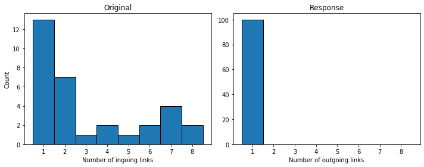

```python
# Histogram of ingoing and outgoing links for the arguments in the NoDe debatepedia test set
fig, (ax1, ax2) = plt.subplots(1,2, figsize=(10,4), sharex=True)  # 1 row, 2 columns

data_set = 'debate_test'
df_plot = pd.concat((data_stats_org[data_set].iloc[:-1],
                     data_stats_resp[data_set].iloc[:-1].rename(
                         columns={'Attacks': 'Attacked', 'Supports': 'Supported'})), keys=['Original', 'Response'])
df_plot.loc['Original'].hist(column=['Total pairs'], ax=ax1, bins=[1,2,3,4,5,6,7,8,9], align='left', ec='black')
df_plot.loc['Response'].hist(column=['Total pairs'], ax=ax2, bins=[1,2,3,4,5,6,7,8,9], align='left', ec='black')

ax1.set_title("Original")
ax2.set_title("Response")
ax1.set_ylabel("Count")
ax1.set_xlabel("Number of ingoing links")
ax2.set_xlabel("Number of outgoing links")
ax1.set_xticks([1,2,3,4,5,6,7,8])
ax1.grid(False)
ax2.set_xticks([1,2,3,4,5,6,7,8])
ax2.grid(False)

plt.tight_layout()
plt.savefig('../data/thesis/node_hist.pdf', bbox_inches='tight')
```

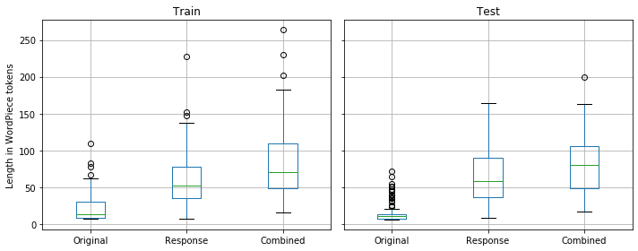

```python
# Boxplot of the lengths of arguments in WordPiece-Tokens for the debatepedia train and test set
fig, ax = plt.subplots(1,2, figsize=(10,4), sharey=True)  # 1 row, 2 columns

#for data_set, ax in [('debate_train', ax1),('debate_test', ax2)]:
df_plot = pd.concat((df[df['org_dataset'] == 'debate_train'], df[df['org_dataset'] == 'debate_test']))
df_plot = df_plot.rename(columns={'org_len': 'Original', 'response_len': 'Response', 'complete_len': 'Combined'})
df_plot = df_plot.replace({'debate_test': 'Test', 'debate_train': 'Train'})
df_plot.groupby('org_dataset', sort=False).boxplot(ax=ax)
ax[0].set_ylabel('Length in WordPiece tokens')
plt.tight_layout()

plt.savefig('../data/thesis/node_length.pdf', bbox_inches='tight')
```

```python
# Political
# General statistics for the dataset
data_stats_topic['political']
```

|  | Topic | Unique arguments | Total pairs | Attack | Support | Unrelated | Median combined tokens | Max combined tokens |
| --- | --- | --- | --- | --- | --- | --- | --- | --- |
| 0 | cuba | 253 | 258 | 38 | 40 | 180 | 216.0 | 531.0 |
| 1 | disarmament | 172 | 314 | 76 | 108 | 130 | 208.5 | 562.0 |
| 2 | medical care,health care | 279 | 289 | 75 | 72 | 142 | 212.0 | 461.0 |
| 3 | minimum wage | 199 | 312 | 125 | 80 | 107 | 208.5 | 460.0 |
| 4 | unemployment | 211 | 287 | 64 | 53 | 170 | 193.0 | 593.0 |
| 5 | Total | 1065 | 1460 | 378 | 353 | 729 | 207.0 | 593.0 |

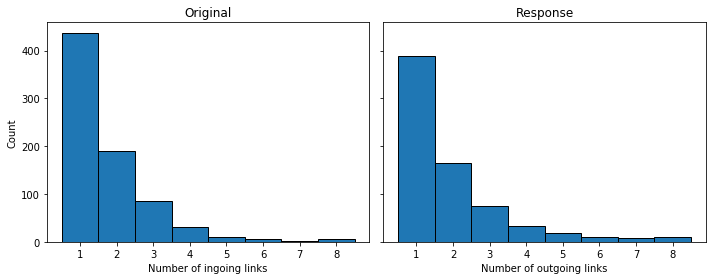

```python
# Histogram of ingoing and outgoing links for the arguments in the Political dataset
fig, (ax1, ax2) = plt.subplots(1,2, figsize=(10,4), sharex=False, sharey=True)  # 1 row, 2 columns

data_set = 'political'
df_plot = pd.concat((data_stats_org[data_set].iloc[:-1],
                     data_stats_resp[data_set].iloc[:-1].rename(
                         columns={'Attacks': 'Attacked', 'Supports': 'Supported'})), keys=['Original', 'Response'])
df_plot.loc['Original'].hist(column=['Total pairs'], bins=[1,2,3,4,5,6,7,8,9], ax=ax1, align='left', ec='black')
df_plot.loc['Response'].hist(column=['Total pairs'], bins=[1,2,3,4,5,6,7,8,9], ax=ax2, align='left', ec='black')

ax1.set_title("Original")
ax2.set_title("Response")
ax1.set_ylabel("Count")
ax1.set_xlabel("Number of ingoing links")
ax2.set_xlabel("Number of outgoing links")
ax1.set_xticks([1,2,3,4,5,6,7,8])
ax1.grid(False)
ax2.set_xticks([1,2,3,4,5,6,7,8])
ax2.grid(False)

plt.tight_layout()

plt.savefig('../data/thesis/political_hist.pdf', bbox_inches='tight')
```

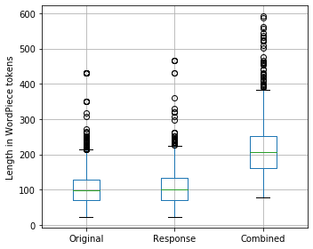

```python
# Boxplot of the lengths of arguments in WordPiece-Tokens for the Political dataset
fig, ax = plt.subplots(1,1, figsize=(5,4), sharey=True)  # 1 row, 2 columns

#for data_set, ax in [('debate_train', ax1),('debate_test', ax2)]:
df_plot = df[df['org_dataset'] == 'political']
df_plot = df_plot.rename(columns={'org_len': 'Original', 'response_len': 'Response', 'complete_len': 'Combined'})
df_plot.groupby('org_dataset', sort=False).boxplot(ax=ax)
ax.set_title("")
ax.set_ylabel('Length in WordPiece tokens')
plt.tight_layout()

plt.savefig('../data/thesis/political_length.pdf', bbox_inches='tight')
```

```python
# Agreement
# General statistics
head = data_stats_topic['agreement'].head().copy()
head.loc[4] = ['...', None, None, None, None, None, None]
ag_short_stats = pd.concat([head, data_stats_topic['agreement'].tail()])
ag_short_stats.to_csv('../data/thesis/agreement_topics_short.csv', encoding='utf-8', index=False)
ag_short_stats
```

|  | Topic | Unique arguments | Total pairs | Agreement | Disagreement | Median combined tokens | Max combined tokens |
| --- | --- | --- | --- | --- | --- | --- | --- |
| 0 | abortion | 155.0 | 446.0 | 221.0 | 225.0 | 183.5 | 638.0 |
| 1 | advertising | 13.0 | 23.0 | 10.0 | 13.0 | 87.0 | 232.0 |
| 2 | alga | 12.0 | 15.0 | 9.0 | 6.0 | 241.0 | 342.0 |
| 3 | algae | 44.0 | 111.0 | 48.0 | 63.0 | 184.0 | 351.0 |
| 4 | ... | NaN | NaN | NaN | NaN | NaN | NaN |
| 160 | wave | 27.0 | 75.0 | 31.0 | 44.0 | 134.0 | 220.0 |
| 161 | weapon | 181.0 | 635.0 | 300.0 | 335.0 | 157.0 | 887.0 |
| 162 | wind | 60.0 | 194.0 | 95.0 | 99.0 | 128.0 | 432.0 |
| 163 | withdrawal | 41.0 | 72.0 | 38.0 | 34.0 | 161.5 | 316.0 |
| 164 | Total | 7951.0 | 29341.0 | 14035.0 | 15306.0 | 181.0 | 1198.0 |

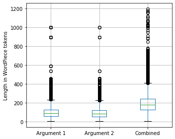

```python
# Boxplot of the lengths of arguments in WordPiece-Tokens for the Agreement dataset
fig, ax = plt.subplots(1,1, figsize=(5,4), sharey=True)  # 1 row, 2 columns

df_plot = df[df['org_dataset'] == 'agreement']
df_plot = df_plot.rename(columns={'org_len': 'Argument 1', 'response_len': 'Argument 2', 'complete_len': 'Combined'})
df_plot.groupby('org_dataset', sort=False).boxplot(ax=ax)
ax.set_title("")
ax.set_ylabel('Length in WordPiece tokens')
plt.tight_layout()

plt.savefig('../data/thesis/agreement_length.pdf', bbox_inches='tight')
```